# HPCC

nikolays

11/30/20

# Metrics

Some of reported HPCC metrics:

- Average Double-Precision General Matrix Multiplication (DGEMM) Floating-Point Performance
  - Embarrassingly parallel, Averaged over all MPI process, MFLOP per Second per MPI process
  - (There is also serial metric; measured but not analysed)
- High Performance LINPACK Floating-Point Performance
  - Parallel, overall MFLOP per Second
- Fast Fourier Transform (FFTW) Floating-Point Performance
  - Parallel, MFLOP per Second
  - (There are also serial and embarrassingly parallel metrics; measured but not analysed)
- Parallel Matrix Transpose (PTRANS)
  - Parallel, overall MByte per Second
- MPI Random Access
  - Parallel, overall MUpdate per Second
  - (There are also serial and embarrassingly parallel metrics; measured but not analysed)
- Average STREAM ‘Triad’/ ‘Add’ / ‘Copy’ / ‘Scale’ Memory Bandwidth
  - Embarrassingly parallel, Averaged over all MPI process, MByte per Second
  - (There is also serial metric; measured but not analysed)

# Results

## Selected metrics

### DGEMM

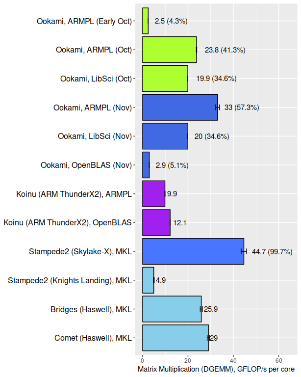

### HPL

number of items to replace is not a multiple of replacement length

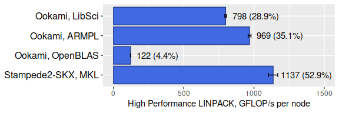

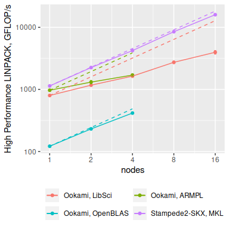

### FFT

number of items to replace is not a multiple of replacement length

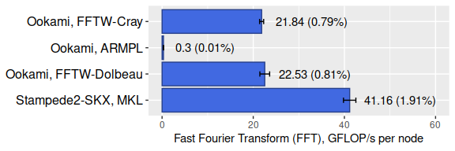

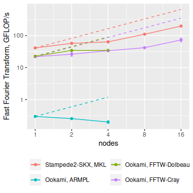

### STREAM

number of items to replace is not a multiple of replacement length

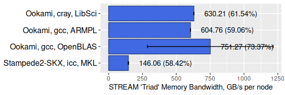

## Overall Performance (That is per All MPI Processes)

### Performance per Core (that is MPI Process)